# Customer Revenue Analysis

SeyedFarzam Mirmoeini - Sinan Lin - Juan Álvarez - Thomas van Dommelen

EIT Digital

May 12, 2020

[video not shown]

[download the notebook](https://mirfarzam.ninja/university/datav/final/final-kaggle.Rmd)

# 0.Recall

In this Google Merchandise Store data set, our task is to build an algorithm that predicts the natural log of the sum of all transactions per user. Thus, for every user in the test set, the target is:

$$y_{user} = \sum_{i=1}^{n} transaction_{user_i}$$

$$target_{user} = \ln({y_{user}+1})$$

Besides, our submissions are scored on the root mean squared error, which is also the metric to measure model performances in our presentation.

# 1.Set up environment

We mainly use library “data.table” to manipulate the data, since it is powerful, faster and SQL-format like.

```r
check.packages <- function(pkg){
  new.pkg <- pkg[!(pkg %in% installed.packages()[, "Package"])]
  if (length(new.pkg))
    install.packages(new.pkg, dependencies = TRUE)
    sapply(pkg, require, character.only = TRUE)
}

show <- function(table, caption = "Data Fields") {
  data <- kable(table, digits = getOption("digits"), caption=caption)
  kable_styling(data,
                font_size = 12)
}

list.of.packages <- c("keras", "car", "pROC","boot","xgboost","lubridate","knitr","MASS","kableExtra","mltools","caret","glmnet","data.table","tidyverse", "rpart","rpart.plot")
check.packages(list.of.packages)
```

```
##      keras        car       pROC       boot    xgboost  lubridate      knitr
##       TRUE       TRUE       TRUE       TRUE       TRUE       TRUE       TRUE
##       MASS kableExtra    mltools      caret     glmnet data.table  tidyverse
##       TRUE       TRUE       TRUE       TRUE       TRUE       TRUE       TRUE
##      rpart rpart.plot
##       TRUE       TRUE
```

# 2.Processing training data

### 2.1.Load Data

```r
dat <- fread("processed_data.csv")
glimpse(dat)
```

```
## Rows: 903,653
## Columns: 33
## $ channelGrouping                <chr> "Organic Search", "Organic Search", "…
## $ date                           <chr> "2016-09-02", "2016-09-02", "2016-09-…
## $ fullVisitorId                  <chr> "1131660440785968512", "3773060208779…
## $ sessionId                      <chr> "1131660440785968503_1472830385", "37…
## $ visitId                        <int> 1472830385, 1472880147, 1472865386, 1…
## $ visitNumber                    <int> 1, 1, 1, 1, 2, 1, 1, 1, 1, 1, 1, 1, 1…
## $ visitStartTime                 <chr> "2016-09-02 15:33:05", "2016-09-03 05…
## $ browser                        <chr> "Chrome", "Firefox", "Chrome", "UC Br…
## $ operatingSystem                <chr> "Windows", "Macintosh", "Windows", "L…
## $ isMobile                       <lgl> FALSE, FALSE, FALSE, FALSE, TRUE, FAL…
## $ deviceCategory                 <chr> "desktop", "desktop", "desktop", "des…
## $ continent                      <chr> "Asia", "Oceania", "Europe", "Asia", …
## $ subContinent                   <chr> "Western Asia", "Australasia", "South…
```

[output cut: 20 more lines]

```r
dat <- dat[1:150000, ]
```

### 2.2.Processing

```r
# get outersection of two vectors
outersect <- function(x, y) {
  sort(c(setdiff(x, y),
         setdiff(y, x)))
}

# some categorical features have too many unique labels, which make them unable to train in our case. Some categorical features have more 90%"

for (i in c("sessionId", "fullVisitorId", "visitId")) {
  cat(i, "'s unique rate : " , length(unique(dat[[i]]))/dim(dat)[1], "\n")
}
```

```
## sessionId 's unique rate :  0.99986
## fullVisitorId 's unique rate :  0.8832667
## visitId 's unique rate :  0.9816667
```

```r
# we also drop features, which are considered carring redundant or useless infomation
drop_cols <- c("adContent", "adwordsClickInfo.adNetworkType", "adwordsClickInfo.gclId", "adwordsClickInfo.page", "adwordsClickInfo.slot", "browser", "city","continent","country", "sessionId", "medium","campaign", "region","keyword","fullVisitorId","metro","networkDomain","referralPath","source","visitId")
dat <- dat[, -..drop_cols]

# feature visitStartTime can be considered a numeric feature
dat <- dat[, visitStartTime:=as.numeric(ymd_hms((visitStartTime)))]
dat <- dat[, ("visitStartTime") := lapply(.SD, scale), .SDcols="visitStartTime"]

# according to data set introduction, the target value "transactionRevenue" is 0. log of transactions is required by this kaggle competition, and it also helps target values to be less skeptical
set(dat, which(is.na(dat[["transactionRevenue"]])), "transactionRevenue", 0)
dat <- dat[, transactionRevenue:=log(transactionRevenue+1)]

# Here are all numeric features in our task
numeric_cols <- c("hits", "pageviews", "visitNumber",  "visitStartTime", 'bounces',  'newVisits', 'transactionRevenue')

# Here are all character features in our task
character_cols <- outersect(colnames(dat), c(numeric_cols,"date"))

# fill missing value
for (colname in numeric_cols) {
  # realistic meaning of NA for numeric data is 0 in our case
  # e.g. if a user didn't click production pages, his/her value of feature "hit"
  # is 0.
  set(dat, which(is.na(dat[[colname]])), colname, 0)
}

for (colname in character_cols) {
  set(dat, which(is.na(dat[[colname]])), colname, "Other")
}

# Group labels that only present very few times to "Other", to simplify the data set, and also improve the generalization ability.
set(dat, which(!dat[["operatingSystem"]] %in% c("Macintosh",
                                                "Chrome OS",
                                                "Android",
                                                "Windows")),
                                                "operatingSystem", "Other")


set(dat, which(!dat[["channelGrouping"]] %in% c("Organic Search",
                                                "Referral",
                                                "Direct",
                                                "Social")),
                                                "channelGrouping", "Other")

# we only consider "subContinent" instead of "country", "city" or "continent". The reason is that feature "country" has more than 200 unique labels. The feature "continent" only has 7 labels, but it is too general and lose too much information.

set(dat, which(dat[["subContinent"]] %in% c("Micronesian Region", "Polynesia",
                                             "Melanesia", "Middle Africa",
                                             "Caribbean", "Central Asia",
                                             "Eastern Africa","Western Africa")),
                                             "subContinent", "Other")

# Factorizing character features, in this way, some models will help us do one-hot encoding internally.
dat[, (character_cols):=lapply(.SD, as.factor), .SDcols=character_cols]


train_set <- subset(dat, date <= ymd(20170303))
test_set <- subset(dat, date > ymd(20170303))
train_set$date <- NULL
test_set$date <- NULL
```

# 2.Baseline

We first build a linear regression with k-fold cross-validation as our baseline. Howover, the summary of the model seems to have confilct with the exploratory data analysis of our previos submission. For example, according to our analysis, “hit” is “hit” is a user’s behavior that has direct relationship with transaction, but the coefficient of “hit” here is negative, and it ususally means that there is an inverse relationship between purchasing and “hit”.

So, we try some statistical analysis over the result.

```r
RMSE <- function(predicted, ground_true){
  sqrt(mean((predicted - ground_true)^2))
}

# some codes borrow from lab
kFold.lm <- function(x, n, K)
{
  set.seed(2020)
  n_folds <- K
  models <- list()
  accuracy <- matrix(NA, nrow = n_folds, ncol = 1)
  folds_i <- sample(rep(1:n_folds, length.out = n)) # generate the folds

  for (k in 1:n_folds) {
    test_i <- which(folds_i == k)

    # Prepare the fold datasets (train and test)
    trainfold <- x[-test_i, ]
    testfold <- x[test_i, ]

    fitted_model <- lm(transactionRevenue ~ .
                       , data=trainfold)
    predictions <- predict(fitted_model, testfold)

    accuracy[k] <- RMSE(testfold$transactionRevenue, predictions)
    # https://stackoverflow.com/questions/5599896/how-do-i-store-arrays-of-statistical-models
    models[[k]] <- fitted_model
  }
  return(list(acc = accuracy,
              models = models))
}

n <- dim(train_set)[1]
K <- 10
res <- kFold.lm(train_set[, ..numeric_cols], n, K)
best_model_index <- which.min(res$acc)
best_fit_lm <- res$models[[best_model_index]]

summary(best_fit_lm)
```

```
##
## Call:
## lm(formula = transactionRevenue ~ ., data = trainfold)
##
## Residuals:
##     Min      1Q  Median      3Q     Max
## -8.2613 -0.0596  0.0123  0.0130  6.8699
##
## Coefficients:
##                  Estimate Std. Error t value Pr(>|t|)
## (Intercept)    -0.0648047  0.0043675 -14.838  < 2e-16 ***
## hits           -0.0310557  0.0008555 -36.302  < 2e-16 ***
## pageviews       0.0718663  0.0012157  59.116  < 2e-16 ***
## visitNumber    -0.0007479  0.0001697  -4.408 1.04e-05 ***
## visitStartTime  0.0006409  0.0025849   0.248    0.804
## bounces         0.0886501  0.0032081  27.633  < 2e-16 ***
## newVisits      -0.0758710  0.0036988 -20.512  < 2e-16 ***
## ---
## Signif. codes:  0 '***' 0.001 '**' 0.01 '*' 0.05 '.' 0.1 ' ' 1
##
## Residual standard error: 0.4245 on 86051 degrees of freedom
## Multiple R-squared:  0.1945, Adjusted R-squared:  0.1944
## F-statistic:  3462 on 6 and 86051 DF,  p-value: < 2.2e-16
```

Multicollinearity is a phenomenon in which one predictor variable in a multiple regression model can be linearly predicted from the others with a substantial degree of accuracy. In other words, there are variables having linear relatedness, which makes the matrix of variables to be rank-deficient. In this way, the coefficients become very sensitive to small changes, and thus weaken the statistical power of our model.

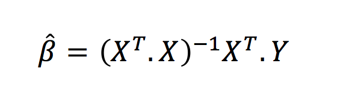

In our previous submission, we also found out that there is a strong relationship between pageview and hit.

```r
car::vif(best_fit_lm)
```

```
##           hits      pageviews    visitNumber visitStartTime        bounces
##      35.958088      37.103714       1.076864       1.006925       1.228387
##      newVisits
##       1.098316
```

We also try a statistical method VIF(variance inflation factor) to detect multicollinearity, and removed the the predictor variables with high VIF value.

After that, we re-train our OLS model, and test our model on test set as our baseline.

```r
n <- dim(train_set)[1]
K <- 10
numeric_cols <- outersect(numeric_cols, "pageviews")
res <- kFold.lm(train_set[, ..numeric_cols], n, K)
best_model_index <- which.min(res$acc)
best_fit_lm <- res$models[[best_model_index]]

summary(best_fit_lm)
```

```
##
## Call:
## lm(formula = transactionRevenue ~ ., data = trainfold)
##
## Residuals:
##     Min      1Q  Median      3Q     Max
## -9.3332 -0.0629  0.0118  0.0197  7.1373
##
## Coefficients:
##                  Estimate Std. Error t value Pr(>|t|)
## (Intercept)     0.0173822  0.0042235   4.116 3.87e-05 ***
## bounces         0.0400834  0.0031634  12.671  < 2e-16 ***
## hits            0.0186931  0.0001568 119.193  < 2e-16 ***
## newVisits      -0.0843444  0.0037703 -22.371  < 2e-16 ***
## visitNumber    -0.0008016  0.0001731  -4.631 3.64e-06 ***
## visitStartTime  0.0080678  0.0026337   3.063  0.00219 **
## ---
## Signif. codes:  0 '***' 0.001 '**' 0.01 '*' 0.05 '.' 0.1 ' ' 1
##
## Residual standard error: 0.4331 on 86052 degrees of freedom
## Multiple R-squared:  0.1618, Adjusted R-squared:  0.1617
## F-statistic:  3321 on 5 and 86052 DF,  p-value: < 2.2e-16
```

We then use the fitted model to predict on the test set, and get our baseline RMSE = 0.463.

```r
predicted <- predict(best_fit_lm, test_set)
lm_rmse <- RMSE(predicted, test_set[, transactionRevenue])
cat("Baseline (RMSE): ", lm_rmse, "\n")
```

```
## Baseline (RMSE):  0.4628971
```

# 3.decision tree

The second method we try is decision tree.

```r
set.seed(2020)
fit_cart <- rpart(
  formula = transactionRevenue ~  .,
  data    = train_set,
  method  = "anova",
  control = list(minsplit = 10, maxdepth = 12, xval = 10, cp = 0.0)
)
tail(fit_cart$cptable)
```

```
##               CP nsplit rel error    xerror       xstd
## 237 1.908941e-05    404 0.5133730 0.8756742 0.02497111
## 238 1.783529e-05    409 0.5132776 0.8757795 0.02497219
## 239 1.579885e-05    410 0.5132598 0.8757280 0.02496358
## 240 1.518434e-05    414 0.5131966 0.8757673 0.02496507
## 241 1.458916e-05    419 0.5131206 0.8757732 0.02496507
## 242 0.000000e+00    422 0.5130769 0.8757859 0.02496160
```

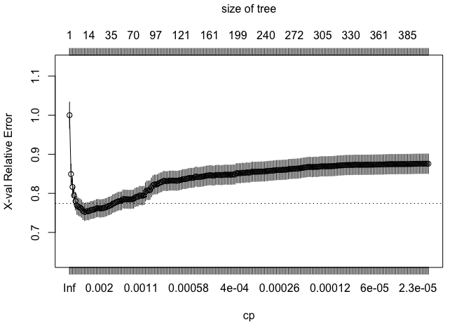

```r
plotcp(fit_cart)
```

Then we try to prune our model to reduces the complexity, and hence improves predictive accuracy by the reduction of overfitting.

```r
# Minimal cost-complexity pruning
optimalCp = fit_cart$cptable[which.min(fit_cart$cptable[,4]),1]
pruned_cart <- prune(fit_cart, cp=optimalCp)
pruned_cart$cptable
```

```
##             CP nsplit rel error    xerror       xstd
## 1  0.164714412      0 1.0000000 1.0000311 0.03352849
## 2  0.028936669      1 0.8352856 0.8492629 0.02569053
## 3  0.021201384      2 0.8063489 0.8163690 0.02441416
## 4  0.011807601      3 0.7851475 0.7946718 0.02342611
## 5  0.010021758      4 0.7733399 0.7800553 0.02282286
## 6  0.008426720      5 0.7633182 0.7685151 0.02239948
## 7  0.008235543      6 0.7548915 0.7656480 0.02226739
## 8  0.007621079      7 0.7466559 0.7638357 0.02225177
## 9  0.005794314      8 0.7390348 0.7610048 0.02212628
## 10 0.003970808      9 0.7332405 0.7551147 0.02192264
## 11 0.003341768     10 0.7292697 0.7524708 0.02192102
```

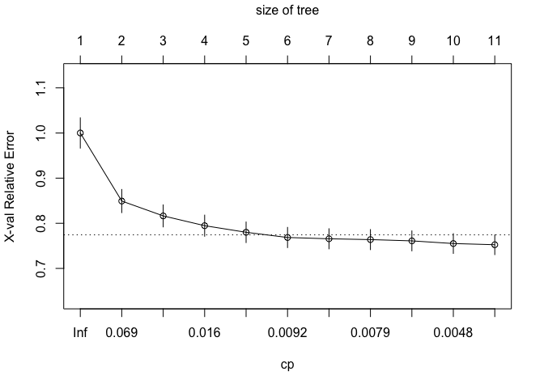

```r
plotcp(pruned_cart)
```

After this, we try a search strategy to tune our model. In our case, we create a hyperparameter grid that will leads to 64 different combinations.

```r
tune_tree <- function(hyper_grid,
                      data) {
  models <- list()

  for (i in 1:nrow(hyper_grid)) {
    # get minsplit, maxdepth values at row i
    minsplit <- hyper_grid$minsplit[i]
    maxdepth <- hyper_grid$maxdepth[i]
    cp <- hyper_grid$cp[i]
    # train a model and store in the list
    models[[i]] <- rpart(
      formula = formula(transactionRevenue ~  .),
      data    = data,
      method  = "anova",
      control = list(minsplit = minsplit, maxdepth = maxdepth, cp = cp)
    )
  }
  return(models)
}

hyper_grid <- expand.grid(
  minsplit = c(5, 15, 30, 50),
  maxdepth = c(5, 12, 17, 20),
  cp = c(0, 0.01, 0.001, 0.0001)
)

# extract the minimum cv error associated with the optimal cost complexity
get_cp <- function(x) {
  min <- which.min(x$cptable[, "xerror"])
  cp <- x$cptable[min, "CP"]
}

get_min_error <- function(x) {
  min    <- which.min(x$cptable[, "xerror"])
  xerror <- x$cptable[min, "xerror"]
}

res <- tune_tree(hyper_grid, data = train_set)

hyper_grid %>%
  # extract the optimal cp and its cross validation error
  mutate(cp = purrr::map_dbl(res, get_cp),
         xerror = purrr::map_dbl(res, get_min_error)) %>%
  arrange(xerror) %>%
  # get top 5 minimal error values
  top_n(-5, wt = xerror)
```

```
##   minsplit maxdepth           cp    xerror
## 1        5        5 0.0008996075 0.7292818
## 2       30        5 0.0001610156 0.7305789
## 3       15        5 0.0010000000 0.7323830
## 4       50        5 0.0006350603 0.7336400
## 5       30        5 0.0010000000 0.7336529
```

Now, after searching better hyperparameters, our model makes a slight improvement over our earlier model with a lower cross validation error 0.738 .

```r
optimal_tree <- rpart(
  formula = transactionRevenue ~  .,
  data    = train_set,
  method  = "anova",
  control = list(minsplit = 5, maxdepth = 5, cp = 0.0001)
)

optimalCp = optimal_tree$cptable[which.min(optimal_tree$cptable[,4]),1]
pruned_cart <- prune(optimal_tree, cp=optimalCp)
pruned_cart$cptable
```

```
##              CP nsplit rel error    xerror       xstd
## 1  0.1647144121      0 1.0000000 1.0000132 0.03352815
## 2  0.0289366689      1 0.8352856 0.8464304 0.02563721
## 3  0.0212013838      2 0.8063489 0.8179635 0.02444578
## 4  0.0118076010      3 0.7851475 0.7895689 0.02320480
## 5  0.0100217580      4 0.7733399 0.7798877 0.02287330
## 6  0.0084267201      5 0.7633182 0.7739969 0.02255206
## 7  0.0082355429      6 0.7548915 0.7699957 0.02242541
## 8  0.0076210791      7 0.7466559 0.7699957 0.02242541
## 9  0.0057943136      8 0.7390348 0.7591890 0.02207797
## 10 0.0039708077      9 0.7332405 0.7538999 0.02186761
## 11 0.0033417677     10 0.7292697 0.7481828 0.02168361
## 12 0.0029767221     11 0.7259279 0.7491137 0.02170509
## 13 0.0028398817     12 0.7229512 0.7490317 0.02164552
## 14 0.0022346953     13 0.7201113 0.7443141 0.02142190
## 15 0.0020435603     14 0.7178766 0.7439201 0.02135171
## 16 0.0016618456     15 0.7158331 0.7431465 0.02133228
## 17 0.0016300030     16 0.7141712 0.7411314 0.02125606
## 18 0.0015281621     17 0.7125412 0.7409866 0.02124625
## 19 0.0014625395     18 0.7110131 0.7405413 0.02122783
## 20 0.0008996075     19 0.7095505 0.7383430 0.02111234
## 21 0.0006912987     20 0.7086509 0.7392943 0.02110462
## 22 0.0003507946     22 0.7072683 0.7384846 0.02107143
## 23 0.0003503705     23 0.7069175 0.7384042 0.02104704
## 24 0.0001610156     25 0.7062168 0.7379686 0.02101978
```

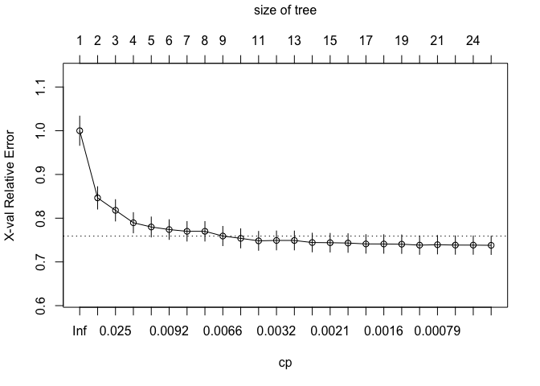

```r
plotcp(pruned_cart)
```

[figure not shown]

```r
rpart.plot(pruned_cart,type=3)
```

Now we try our optimal tree model on our test_set, and we get a RMSE 0.426, that successfuly defeat our baseline model.

```r
predictted <- predict(pruned_cart, test_set, type = 'vector')
dt_rmse <- RMSE(predictted, test_set[, transactionRevenue])
cat("Pruned Decision Tree(RMSE): ", dt_rmse, "\n")
```

```
## Pruned Decision Tree(RMSE):  0.4258462
```

# 4.Logistic Regression

Our data set is highly imbalanced, since purchasing doesn’t happen in 90% of the user records. Consequently, it bias the prediction of our models.

In this part, we build a two-level hierarchical algorithm combining classification and regression and split the task into two steps. First, we build a binary classifier to detect whether there is transaction. Second, if true, we apply a regression method to predict the revenue. Otherwise, revenue is 0.

```r
# logistic Kfold
kFold.logistic <- function(x, n, K)
{
  n_folds <- K
  model <- list()
  accuracy <- matrix(NA, nrow = n_folds, ncol = 1)
  folds_i <- sample(rep(1:n_folds, length.out = n)) # generate the folds

  for (k in 1:n_folds) {
    test_i <- which(folds_i == k)

    # Prepare the fold datasets (train and test)
    trainfold <- x[-test_i, ]
    testfold <- x[test_i, ]

    # Now feed it to glm
    fitted_model <- glm(y_has_revenue ~  . , data=trainfold, family="binomial")

    # Test the model on test fold
    predictions <- predict(fitted_model, testfold, type='response')
    predictions.results <- ifelse(predictions > 0.5, 1, 0)

    accuracy[k] <- sum(predictions.results == testfold[, y_has_revenue])/length(test_i)
    model[[k]] <- fitted_model
  }
  return(list(acc = accuracy,
              models = model))
}

n <- dim(train_set)[1]
K <- 10

y_has_revenue <- as.factor(ifelse(train_set$transactionRevenue > 0, 1, 0))
train_set <- cbind(train_set, y_has_revenue)

res <- kFold.logistic(train_set[, -"transactionRevenue"], n, K)

acc <- res$acc
rownames(acc) <- paste("fold-",1:10,sep="")
colnames(acc) <- "accuracy"
show(acc)
```

Data Fields

|  | accuracy |
| --- | --- |
| fold-1 | 0.9874503 |
| fold-2 | 0.9896465 |
| fold-3 | 0.9881824 |
| fold-4 | 0.9854633 |
| fold-5 | 0.9892282 |
| fold-6 | 0.9890190 |
| fold-7 | 0.9880778 |
| fold-8 | 0.9872412 |
| fold-9 | 0.9878686 |
| fold-10 | 0.9874503 |

```r
# choose the model having the highest accuracy in cross validation
best_model_index <- which.max(res$acc)
best_logistic_fitted <- res$models[[best_model_index]]
```

Then we try to find an optimal threshold based on false positive rate and the false negative rate.

```r
get_logistic_pred <- function(mod, data,  pos = 1, neg = 0, cut = 0.5) {
  probs = predict(mod, newdata = data, type = "response")
  pred <- ifelse(probs > cut, pos, neg)
  return(pred)
}

find_threshold.logistic <- function(model, test_x, test_y,
                                    thresholds =c(0.1, 0.3, 0.5, 0.7, 0.9)) {
  metrics <- NULL
  for (i in 1:length(thresholds)) {
    test_pred <- get_logistic_pred(model, data = test_x,
                                       pos = 1, neg = 0,
                                       cut = thresholds[i])
    test_pred_table <- table(predicted = test_pred, actual = test_y)
    test_con_mat <- confusionMatrix(test_pred_table, positive = "1")
    metrics <- rbind(metrics, c(test_con_mat$overall["Accuracy"],
                               test_con_mat$byClass["Sensitivity"],
                               test_con_mat$byClass["Specificity"]))
  }

  rownames(metrics) <- paste("cutoff=", thresholds, sep="")
  return(metrics)
}

y_has_revenue_test <- as.factor(ifelse(test_set$transactionRevenue > 0, 1, 0))

metrics <- find_threshold.logistic(best_logistic_fitted,
                                   test_x = test_set[, -"transactionRevenue"],
                                   test_y = y_has_revenue_test,
                                   thresholds = c(0.1, 0.3, 0.5, 0.7, 0.9))
show(metrics, "")
```

|  | Accuracy | Sensitivity | Specificity |
| --- | --- | --- | --- |
| cutoff=0.1 | 0.9816661 | 0.6440678 | 0.9868731 |
| cutoff=0.3 | 0.9854174 | 0.2227603 | 0.9971804 |
| cutoff=0.5 | 0.9853071 | 0.1125908 | 0.9987676 |
| cutoff=0.7 | 0.9849945 | 0.0581114 | 0.9992904 |
| cutoff=0.9 | 0.9848474 | 0.0266344 | 0.9996265 |

we also can use ROC curve to find the optimal threshold

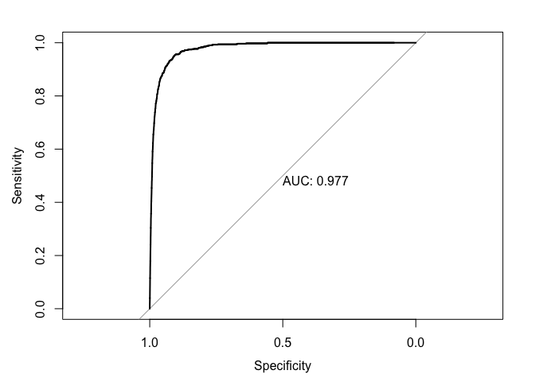

```r
probs = predict(best_logistic_fitted, newdata = test_set, type = "response")
test_roc = roc(y_has_revenue_test ~ probs, plot = TRUE, print.auc = TRUE)
```

```r
(best_threshold <- coords(test_roc, "best", transpose = TRUE))
```

```
##   threshold specificity sensitivity
##   0.0243532   0.9054599   0.9539952
```

```r
logistic_clf <- function(x, cutoff) {
  probs = predict(best_logistic_fitted, newdata = x, type = "response")
  predicted <- ifelse(probs > cutoff, 1, 0)
  return(predicted)
}

stack_predictor <- function(model_clf, model_reg, x, cutoff) {
  hasRevenue <- model_clf(x, cutoff)
  hasRevenue_idx <- which(hasRevenue == 1)
  pred_revenue <- predict(model_reg, x[hasRevenue_idx, ])
  hasRevenue[hasRevenue_idx] <- pred_revenue
  return(hasRevenue)
}

pred_revenue <- stack_predictor(logistic_clf, best_fit_lm, test_set, best_threshold[[1]])
stack_logistic_lm_rmse <- RMSE(test_set[, transactionRevenue], pred_revenue)
cat("Logistic regression with linear regression (RMSE): ", stack_logistic_lm_rmse, "\n")
```

```
## Logistic regression with linear regression (RMSE):  0.4560517
```

```r
pred_revenue_dt <- stack_predictor(logistic_clf,
                                optimal_tree,
                                test_set,
                                best_threshold[[1]])
stack_logistic_cart_rmse <- RMSE(test_set[, transactionRevenue], pred_revenue_dt)
cat("Logistic regression with Decision Tree (RMSE): ", stack_logistic_cart_rmse, "\n")
```

```
## Logistic regression with Decision Tree (RMSE):  0.4234778
```

# 5.Advanced Methods

In the final part, we explore two advanced methods – neural networks and xgboost

## 5.1.Neural Networks

Multilayer perceptron is a popular deep learning tool for regression task. Unlike the traditional MLP network, we add two dropout layer to this model, which help to improve the generalization ability to avoid overfitting.

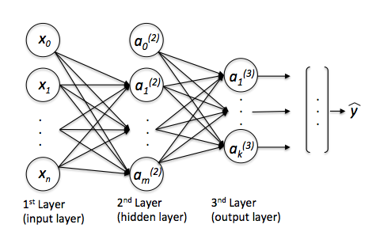

```r
set.seed(2020)
features_rm <- c("y_has_revenue", "pageviews", numeric_cols)
one_hot_X <- one_hot(train_set[, -..features_rm])
features_rm <- c("pageviews", numeric_cols)
X <- cbind(train_set[, ..features_rm], one_hot_X)
y <- X$transactionRevenue
X$transactionRevenue <- NULL
X <- as.matrix(X)

m_nn <- keras_model_sequential()

m_nn %>%
  layer_dense(units = 256, activation = "relu", input_shape = ncol(X)) %>%
  layer_dropout(rate = 0.5) %>%
  layer_dense(units = 128, activation = "relu") %>%
  layer_dropout(rate = 0.25) %>%
  layer_dense(units = 1, activation = "linear")


(m_nn %>% compile(loss = "mean_squared_error",
         metrics = custom_metric("rmse", function(y_true, y_pred)
         k_sqrt(metric_mean_squared_error(y_true, y_pred))),
         optimizer = optimizer_adadelta()))
```

```
## Model
## ________________________________________________________________________________
## Layer (type)                        Output Shape                    Param #
## ================================================================================
## dense (Dense)                       (None, 256)                     9472
## ________________________________________________________________________________
## dropout (Dropout)                   (None, 256)                     0
## ________________________________________________________________________________
## dense_1 (Dense)                     (None, 128)                     32896
## ________________________________________________________________________________
## dropout_1 (Dropout)                 (None, 128)                     0
## ________________________________________________________________________________
## dense_2 (Dense)                     (None, 1)                       129
## ================================================================================
## Total params: 42,497
## Trainable params: 42,497
## Non-trainable params: 0
## ________________________________________________________________________________
```

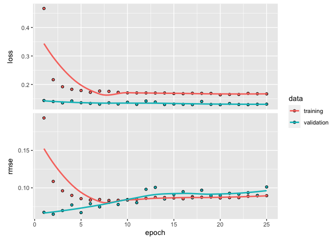

```r
history <-fit (m_nn, x = X, y = y,
      epochs = 50,
      batch_size = 128,
      verbose = 30,
      validation_split = 0.2,
      callbacks = callback_early_stopping(patience = 5))
history$params$epochs <- length(history$metrics$val_loss)
plot(history)
```

```r
features_rm <- c("pageviews", numeric_cols)
X_test <- one_hot(test_set[, -..features_rm])
one_hot_x <- one_hot(test_set[, -..features_rm])
X_test <- cbind(test_set[, ..features_rm], one_hot_x)
y_test <- X_test$transactionRevenue
X_test$transactionRevenue <- NULL
X_test <- as.matrix(X_test)
pred_nn <- predict(m_nn, X_test)
nn_rmse <- RMSE(y_test, pred_nn)
cat("Nueral network (RMSE): ", nn_rmse, "\n")
```

```
## Nueral network (RMSE):  0.4166167
```

## 5.2.Xgboost

Xgboost is a highly efficient gradient boosting tool/library, and it is also one of the most popular machine learning tools people use in Kaggle competition. Gradient boosting that combines weak “classifiers” into a single strong learner, and update the weight of weak “classifiers” and the distribution of data every iteration. Similarly, xgboost also follows the principle of gradient boosting. There are, however, the difference in modeling implementation details. For example, xgboost used a more regularized model formalization to avoid over-fitting, and add many engineering features into the model(automatically fill missing values).

```r
set.seed(2020)
dtrain <- xgb.DMatrix(X,
                      label = y)
dtest <- xgb.DMatrix(X_test,
                      label = y_test)

params <- list(objective = "reg:linear",
               booster = "gbtree",
               eval_metric = "rmse",
               nthread = 4,
               eta = 0.05,
               max_depth = 7,
               min_child_weight = 5,
               gamma = 0,
               subsample = 0.8,
               colsample_bytree = 0.7,
               colsample_bylevel = 0.6,
               nrounds = 100
         )
m_xgb <- xgb.train(data = dtrain,
                   params = params,
                   nrounds= 50,
                   print_every_n = 20)


y_pred <- predict(m_xgb, dtest)
xgb_rmse <- RMSE(test_set[, transactionRevenue], y_pred)
cat("Xgboost (RMSE): ", xgb_rmse, "\n")
```

```
## Xgboost (RMSE):  0.427447
```

# 6. Result

```r
res <- as.matrix(c(lm_rmse,
                   stack_logistic_lm_rmse,
                   dt_rmse,
                   stack_logistic_cart_rmse,
                   xgb_rmse,
                   nn_rmse))

rownames(res) <- c( "OLS Regression",
                    "OLS Regression with logitstic",
                    "Decison Tree",
                    "Decison Tree with logitstic",
                    "Xgboost",
                    "Neural Network")
colnames(res) <- "RMSE"
show(res, "Model performances")
```

Model performances

|  | RMSE |
| --- | --- |
| OLS Regression | 0.4628971 |
| OLS Regression with logitstic | 0.4560517 |
| Decison Tree | 0.4258462 |
| Decison Tree with logitstic | 0.4234778 |
| Xgboost | 0.4274470 |
| Neural Network | 0.4166167 |